# XGBoost Quick Start Demo

Garvey

2017年6月8日

```r
# set global options
knitr::opts_chunk$set(fig.width=12, fig.height=8, fig.path='Figs/',
                      include=TRUE,echo=TRUE, warning=FALSE, message=FALSE)
```

## 1.Load Data

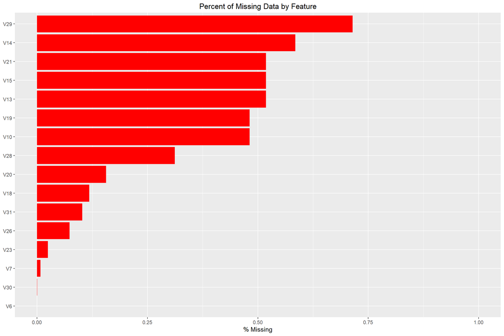

```r
load("data//data1.RData")
# block variable names
colnames(data1)=sprintf("V%s",seq(1:ncol(data1)))
na.plot(data1)  # plot proportion of NA
```

## 2.XGB quick start

### 2.1 Data Pre-Processing

```r
#head(train)
dtrain <- xgb.DMatrix(train, label = data1$y,missing=NA)
xgb1 <- xgboost(data = dtrain, max.depth = 4,missing=NA,
               eta = 1, nthread = 2, nround = 10,objective = "binary:logistic")
save(xgb1,file="model//xgb1.RData")  # save the model to aviod repeted? training
```

```r
load("model//xgb1.RData") # Load the trained model for saving time
```

### 2.2 KS Value

```r
y_hat=predict(xgb1,newdata=as.matrix(train),missing=NA)
ks.test(y_hat[which(data1$y==1)],y_hat[which(data1$y==0)])
```

```
##
##  Two-sample Kolmogorov-Smirnov test
##
## data:  y_hat[which(data1$y == 1)] and y_hat[which(data1$y == 0)]
## D = 0.26814, p-value < 2.2e-16
## alternative hypothesis: two-sided
```

```r
#auc(data1$y, y_hat)  #0.6873
```

### 2.3 Importance of Feature

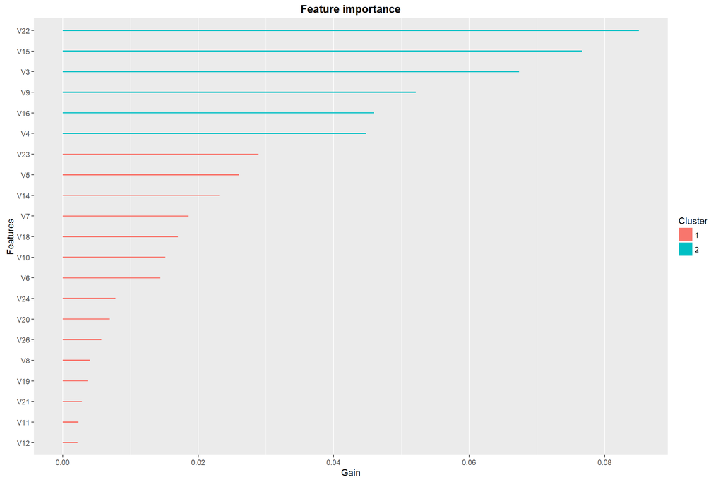

### 2.4 Apply CV on XGBoost

当时考虑单机训练速度问题，没有采用grid search,而是仅观察单个参数递增时十折交叉检验的均值和方差的变化来进行选参。

```r
history <- xgb.cv(data = dtrain, nround=100, nthread = 2, nfold = 10, metrics=list("auc","rmse","error"),
                  max.depth =6, eta = 1, objective = "binary:logistic")
history=history%>%data.frame
save(history,file="data//history.RData")
```

#### AUC

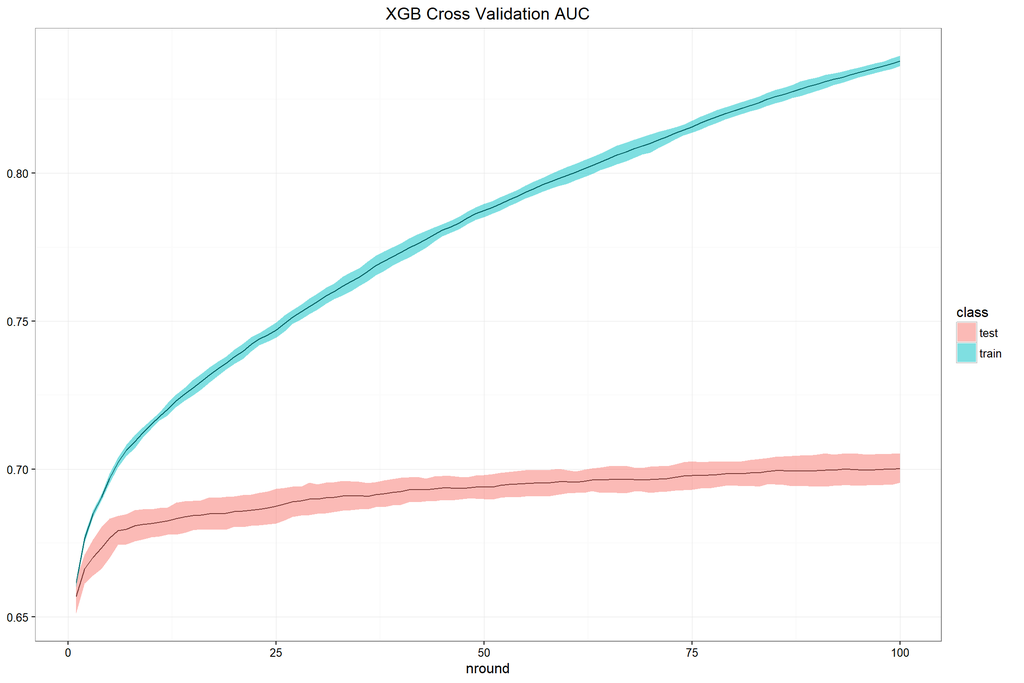

#### RMSE

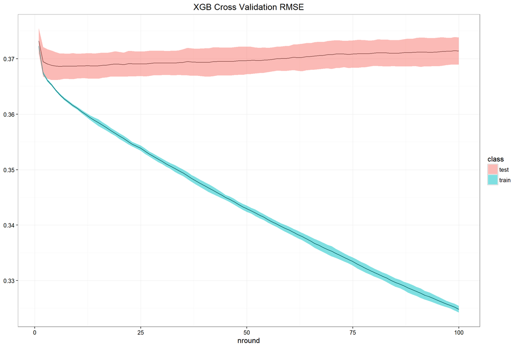

#### ERROR

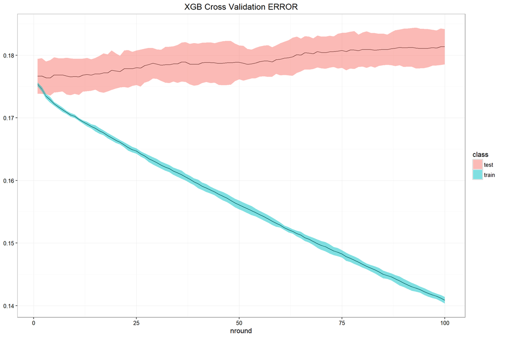

## 3.Feature Engineering

### 3.1 City Feature

### Data2

- 修复“广西”、“广西省”名字歧义问题
- 针对地区追加网上的信息：
  - 地区人均GDP以及相应排名
  - [2015年商业银行地区不良率](http://www.sohu.com/a/110107248_151848)
  - 对应地区历史逾期率
- 尝试追加xgb1的迭代特征

|  | ABODE_STATE_Value | perGDP | perGPD_order | bad_ratio1 | bad_ratio2 |
| --- | --- | --- | --- | --- | --- |
| 1 | 安徽省 | 11180 | 5 | 1.86 | 0.157514450867052 |
| 2 | 福建省 | 23663 | 23 | 2.77 | 0.19375 |
| 3 | 甘肃省 | 9527 | 4 | 1.13 | 0.180024660912454 |
| 4 | 广东省 | 32142 | 27 | 1.43 | 0.173350977198697 |
| 5 | 广西省 | 11417 | 6 | 2.18 | 0.196772191185599 |
| 6 | 贵州省 | 6742 | 1 | 1.6 | 0.222796651895618 |
| 7 | 海南省 | 13361 | 14 | 1.67 | 0.141818181818182 |
| 8 | 河北省 | 19363 | 22 | 1.18 | 0.154981549815498 |
| 9 | 河南省 | 15056 | 17 | 1.48 | 0.158779241731648 |
| 10 | 黑龙江省 | 18463 | 21 | 1.72 | 0.205882352941176 |

[output cut: 19 more lines]

#### AUC

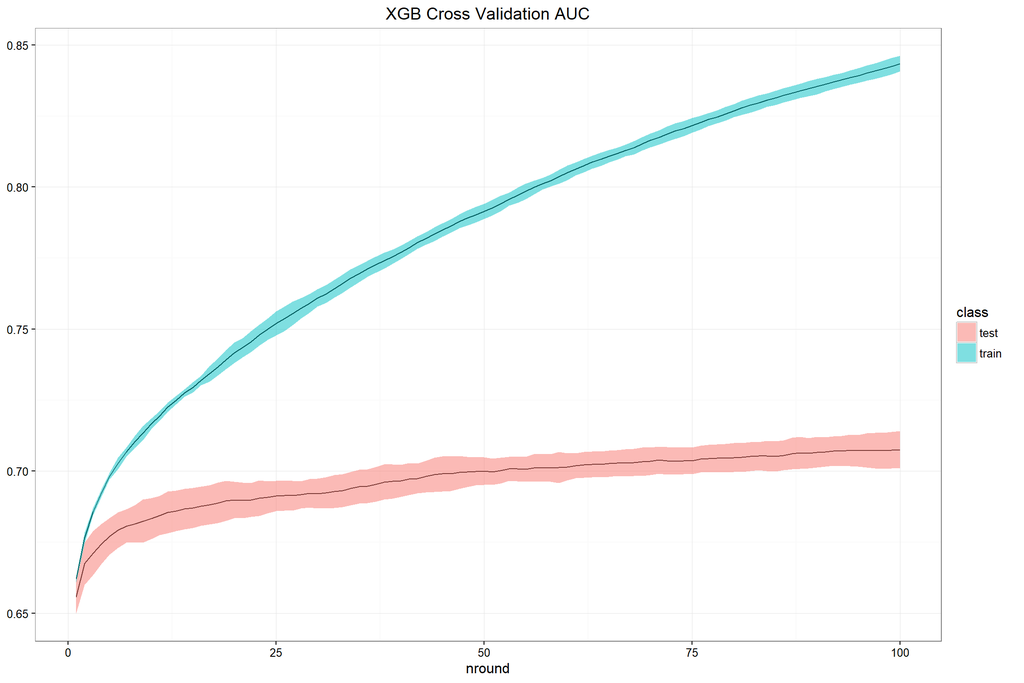

#### RMSE

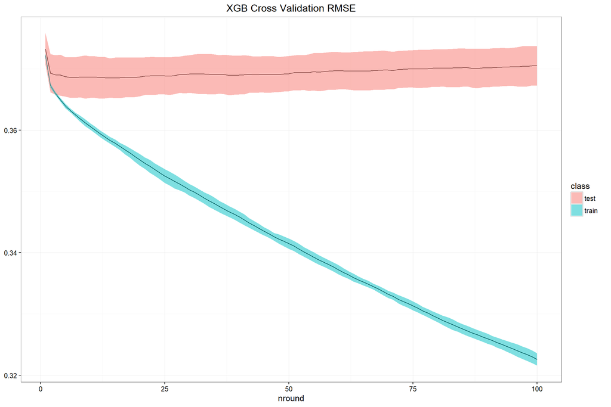

#### ERROR

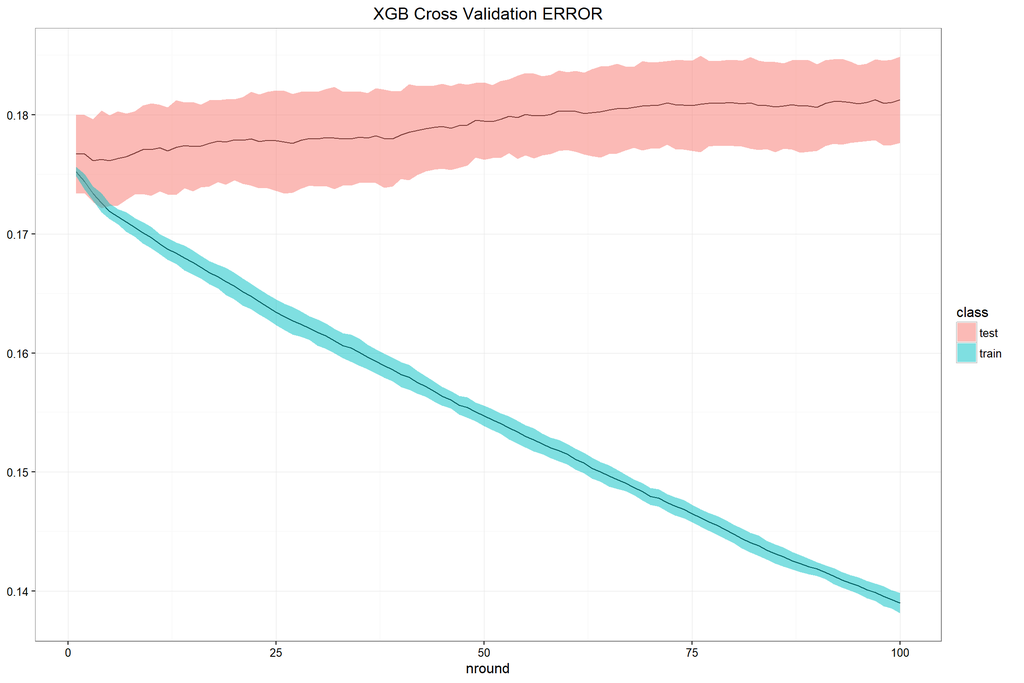

#### AUC_xgb1

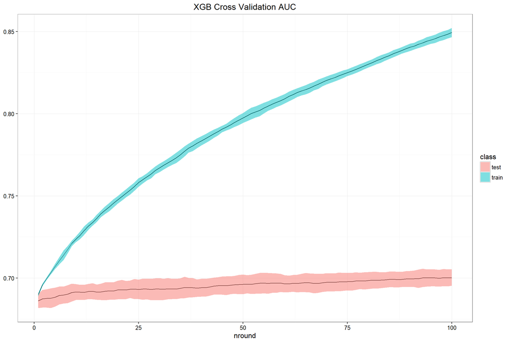

#### RMSE_xgb1

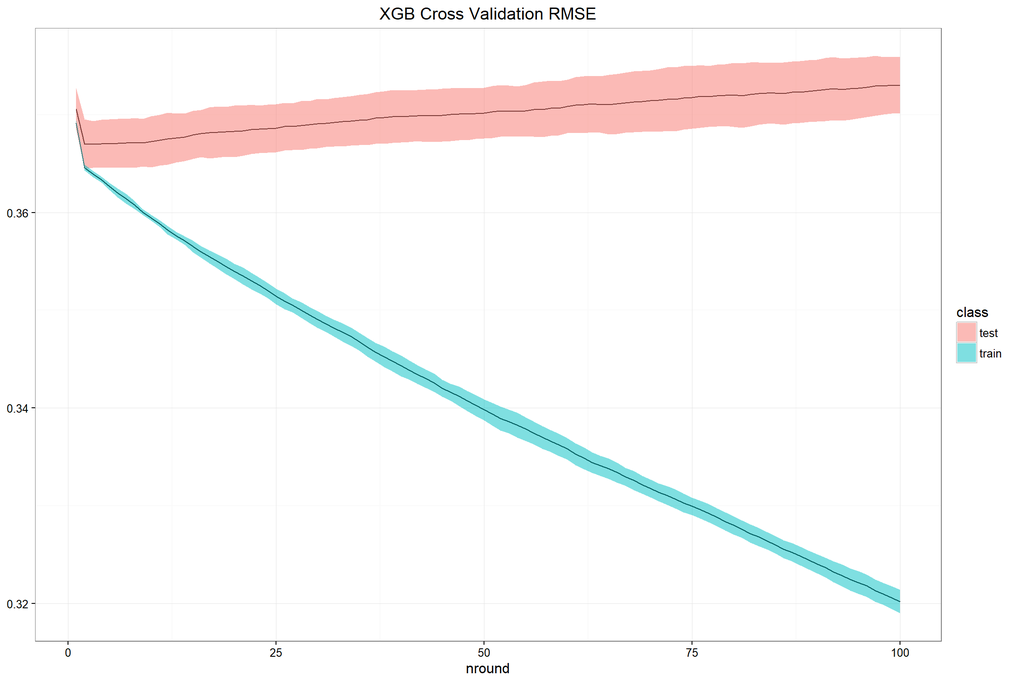

#### ERROR_xgb1

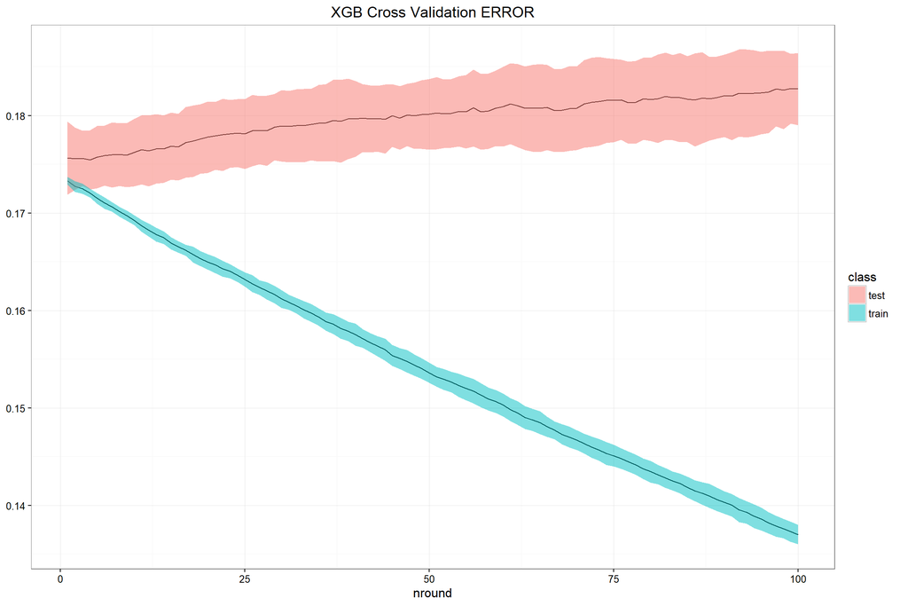

### 图像分析

- AUC up，AUC方差up
- RMSE,ERROR down，方差基本不变

### 3.2 Time Feature

### Data3

- 增加变量work2loan
- 增加时间窗口sofar，计算订单生成到今年六月的时间差，units是月份
- 增加worktime
- 增加weekdays,weekend,month,day字段
- 增加age/worktime的复合字段(age2worktime,age_worktime_ratio)

#### AUC

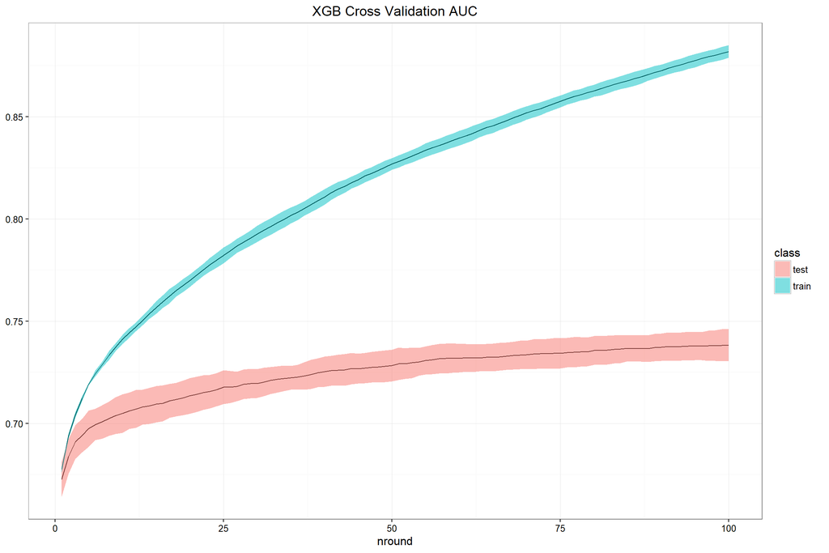

#### RMSE

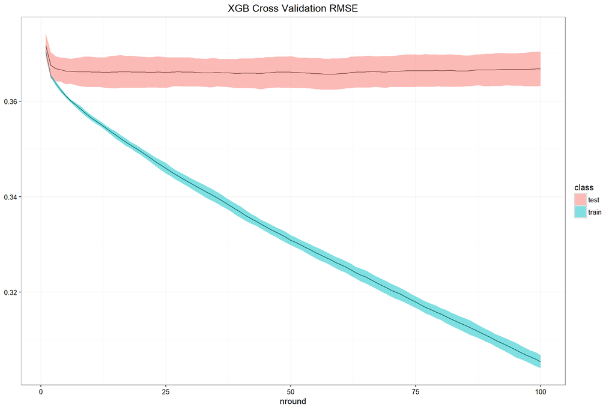

#### ERROR

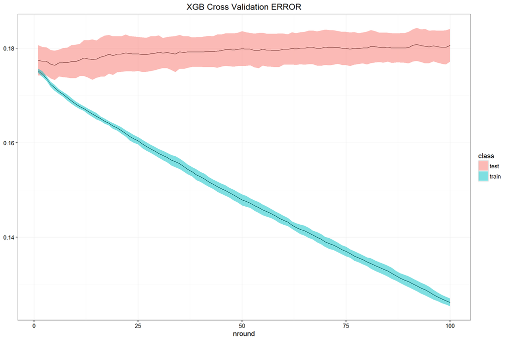

#### AUC_xgb1

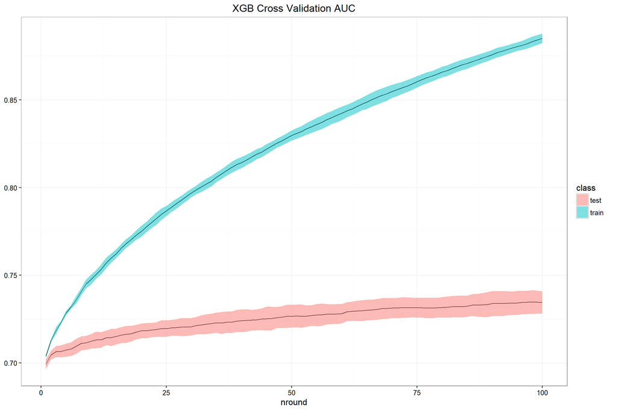

#### RMSE_xgb1

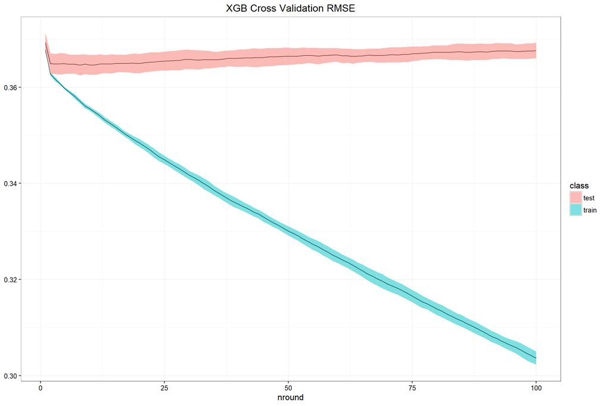

#### ERROR_xgb1

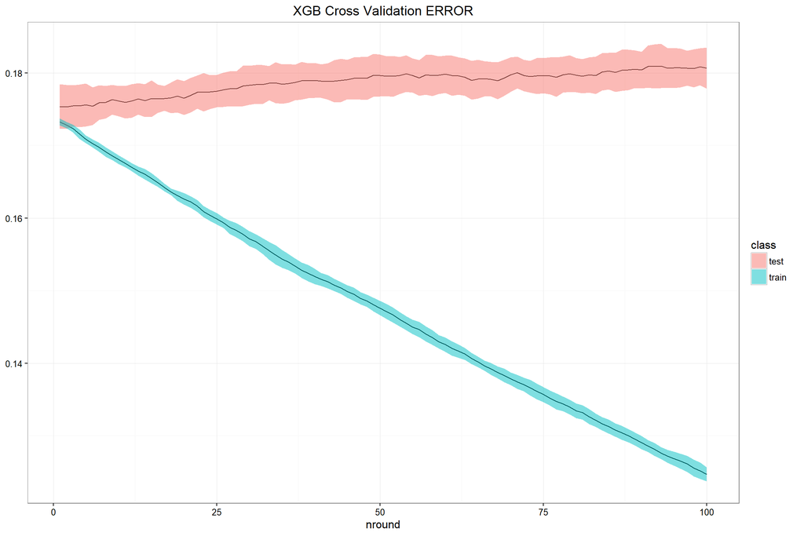

### 3.3 NA Feature

### Data4

- 增加三个NA数量标签
- 删除NA极端点(6个离群样本)

## 4.Coarse tuning with new features

### 4.1 Run XGB2 with new features

```r
dtrain <- xgb.DMatrix(train, label = data4$y,missing=NA)
xgb2 <- xgboost(data = train, label=data4$y%>%as.matrix,max.depth = 4,missing=NA,
               eta = 1, nthread = 2, nround = 10,objective = "binary:logistic")


save(xgb2,file="model//xgb2.RData")
save(train,file="data//train_data4.RData")
```

### 4.2 Glance new KS value

```
##
##  Two-sample Kolmogorov-Smirnov test
##
## data:  y_hat[which(data4$y == 1)] and y_hat[which(data4$y == 0)]
## D = 0.31689, p-value < 2.2e-16
## alternative hypothesis: two-sided
```

```r
history4 <- xgb.cv(data = train, label=as.matrix(data4$y),missing=NA,nround=100, nthread = 2, nfold = 10, metrics=list("auc","rmse","error"),
                  max.depth =6, eta = 1, objective = "binary:logistic")
history4=history4%>%data.frame
save(history4,file="data//history4.RData")
```

```r
ks=function(pres,dtrain){
  labels <- getinfo(dtrain, "label")
  a=ks.test(pres[which(labels==1)],pres[which(labels==0)])
  return(list(metric = "ks", value = a$statistic))
}
history4_ks=xgb.cv(data = train, label=as.matrix(data4$y),missing=NA,nround=100, nthread = 2, nfold = 10,
      feval=ks,max.depth =6, eta = 1, objective = "binary:logistic")
history4_ks=history4_ks%>%data.frame
save(history4_ks,file="data//history4_ks.RData")
```

#### AUC

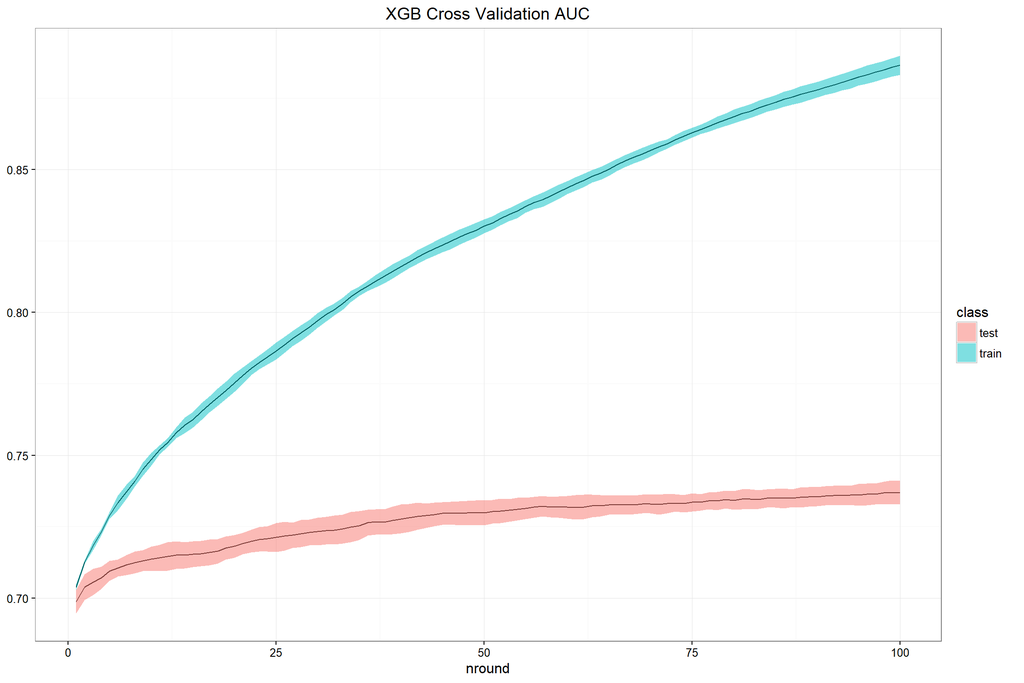

#### RMSE

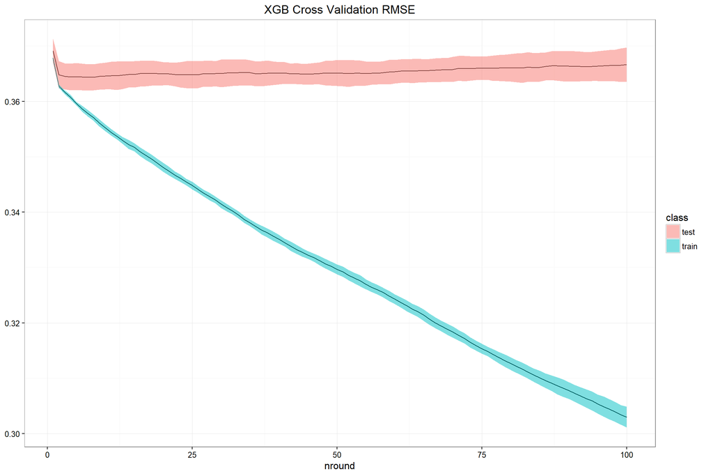

#### ERROR

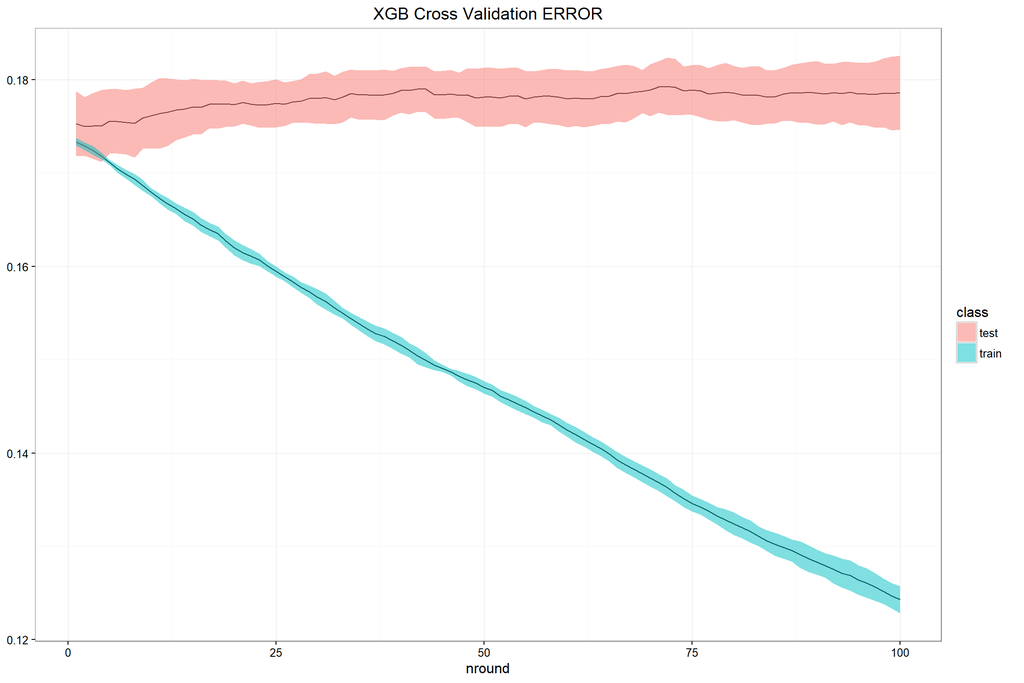

#### KS

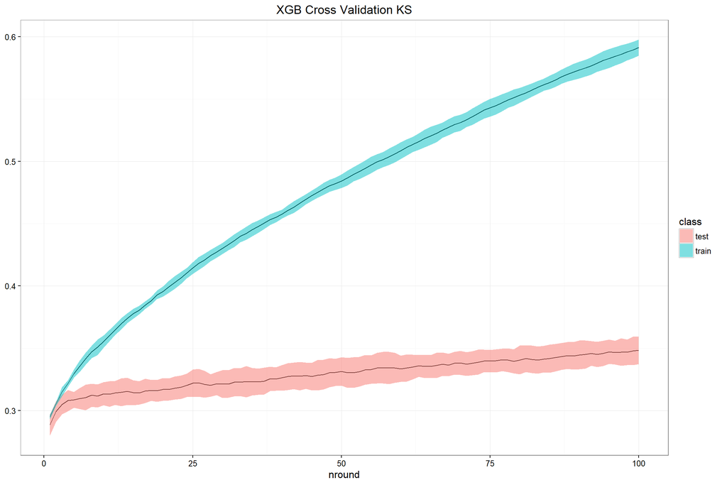

### 4.5 Show importance of feature

#### All Feature

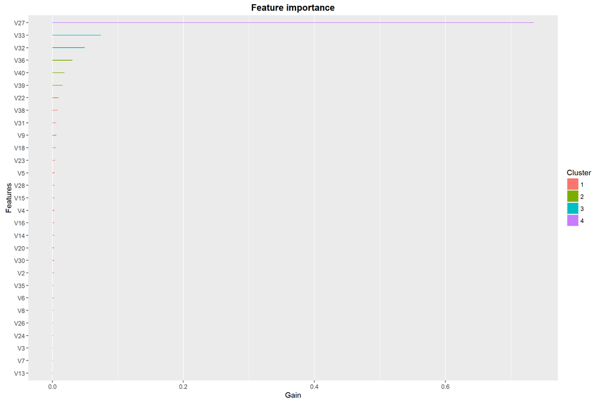

```r
# importanceRaw <- xgb.importance(feature_names=colnames(train), model = xgb2)
# Block varible names
importanceRaw <- xgb.importance(feature_names=sprintf("V%s",seq(1:ncol(train))), model = xgb2)
xgb.plot.importance(importanceRaw)
```